# wineQuality

# Data Analyst Nanodegree, Term 2 Project 2: EDA

Jesse Fredrickson

10/23/18

The purpose of this project is to perform exploratory data analysis (EDA) on a dataset - I have elected to analyze a dataset involving the chemical properties of white wine. I will do some basic analysis on select variables, and try to investigate the relationships between wine properties and wine quality as judged by professional wine tasters. I will start by loading the dataset and doing some basic 1 variable plots and analysis to understand the data.

```
## 'data.frame':    4898 obs. of  13 variables:
##  $ X                   : int  1 2 3 4 5 6 7 8 9 10 ...
##  $ fixed.acidity       : num  7 6.3 8.1 7.2 7.2 8.1 6.2 7 6.3 8.1 ...
##  $ volatile.acidity    : num  0.27 0.3 0.28 0.23 0.23 0.28 0.32 0.27 0.3 0.22 ...
##  $ citric.acid         : num  0.36 0.34 0.4 0.32 0.32 0.4 0.16 0.36 0.34 0.43 ...
##  $ residual.sugar      : num  20.7 1.6 6.9 8.5 8.5 6.9 7 20.7 1.6 1.5 ...
##  $ chlorides           : num  0.045 0.049 0.05 0.058 0.058 0.05 0.045 0.045 0.049 0.044 ...
##  $ free.sulfur.dioxide : num  45 14 30 47 47 30 30 45 14 28 ...
##  $ total.sulfur.dioxide: num  170 132 97 186 186 97 136 170 132 129 ...
##  $ density             : num  1.001 0.994 0.995 0.996 0.996 ...
##  $ pH                  : num  3 3.3 3.26 3.19 3.19 3.26 3.18 3 3.3 3.22 ...
##  $ sulphates           : num  0.45 0.49 0.44 0.4 0.4 0.44 0.47 0.45 0.49 0.45 ...
##  $ alcohol             : num  8.8 9.5 10.1 9.9 9.9 10.1 9.6 8.8 9.5 11 ...
##  $ quality             : int  6 6 6 6 6 6 6 6 6 6 ...
```

# Initial Observations

1. The dataset consists of almost 5000 observations, and 13 variables
2. The X variable appears to be an index number, I will ignore it most cases
3. I will likely want to compare everything to quality
4. Need to do research on acids, sugars, chlorides, and sulfurs + sulfites in winemaking to get some concept of how they relate
5. May need to investigate collinearity between some variables
6. Although there are 3 variables pertaining to acidity, one is an order of magnitude higher than the others and it may not make sense to combine them in any sense
7. The quality variable is integers (continuous), and I will want to factor it for some plots in order to use it as a categorical variable

# Winemaking Research

Sulfur Dioxide [mg/L]: is added to preserve wine due to its antimicrobial properties. It is also a product of fermentation. Total sulfer dioxide is free + bound, where bound sulfur dioxide has exhausted its preservative usefulness and bound to sugars, acetaldehyde, and phenolic compounds.

Acidity [g/L]: Acids change the pH of the wine, cut the taste of sugar, and enhance the effectiveness of sulfur dioxides. Fixed acidity refers to Tantric acid, Volatile acidity mainly refers to Acetic acid, and Citric acidity of course refers to citric acid. It is desired to have a balance of acidity and sweetness (residual sugar).

Residual Sugar [g/L]: lends sweetness to wine (cuts dryness). Sugar is a reagent in the fermentation process by which yeast produces alcohol.

Chlorates [g/L]: refers to Sodium Chloride, analogous to salt in wines.

Sulphates [g/L]: refers to Potassium Sulphate.

Density: Alcohol is less dense than sugar, therefore as sugar is consumed during fermentation and alcohol is produced, the density goes down.

# Univariate Plots

The variable I care most about is quality. I will first look at the distribution of quality rankings

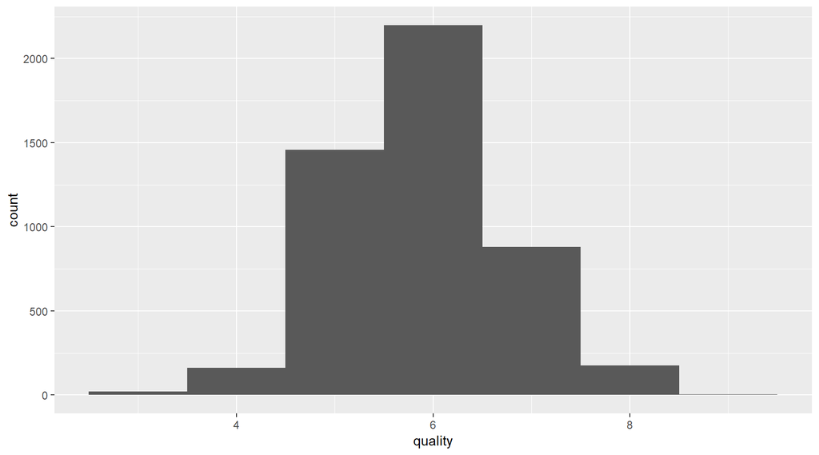

```
##    Min. 1st Qu.  Median    Mean 3rd Qu.    Max.
##   3.000   5.000   6.000   5.878   6.000   9.000
```

Wine quality appears to follow a normal distribution, centered around rating of 6. There are only 7 wine ratings that are actually in use between 3 and 9. This distribution is good because I should have enough data points to differentiate between poor quality (<6) and good quality (>6) wines.

Next I will create a histogram of alcohol content.

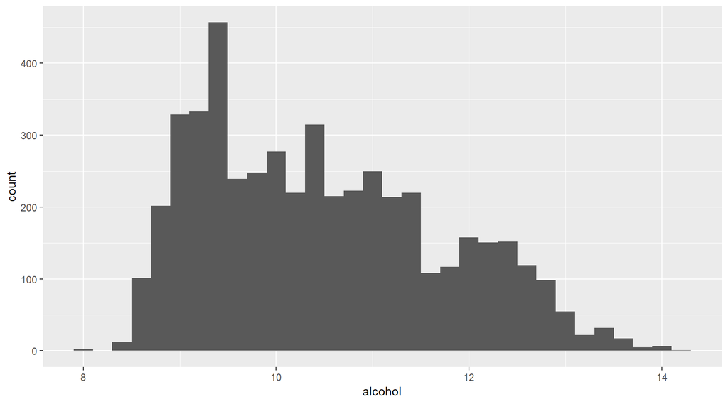

I will show one more histogram on density, since it is another easy to understand variable.

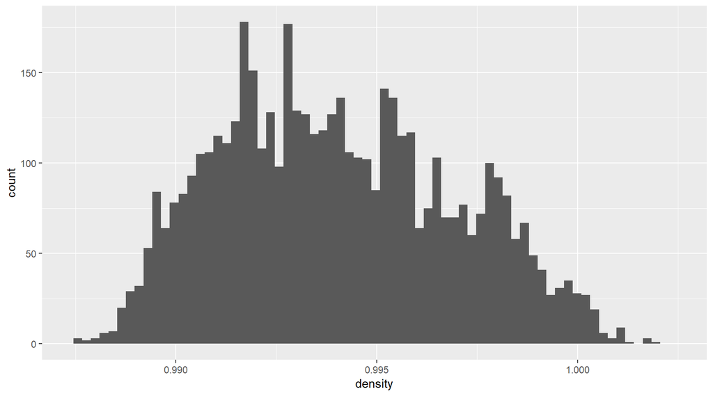

Again we see a nice distribution, appearing fairly normal. There does appear to be a pair of peaks on the right half of the distribution, but it is not clear if they are significant.

Next I will try examining residual sugar.

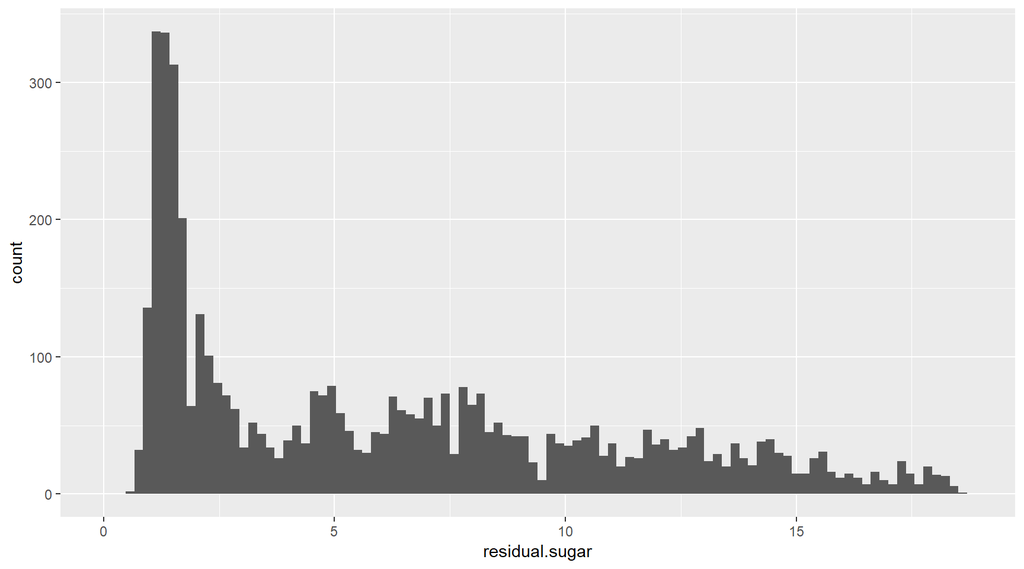

I will also be interested in the acidity of wines.

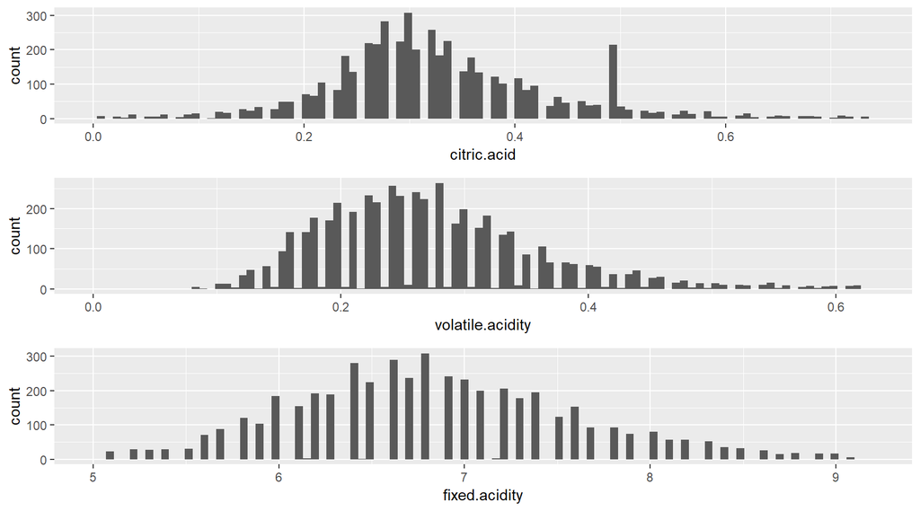

Each of these plots follows a normal distribution, excepting citric acid, which has a large spike at approximately .5.

Similarly with pH

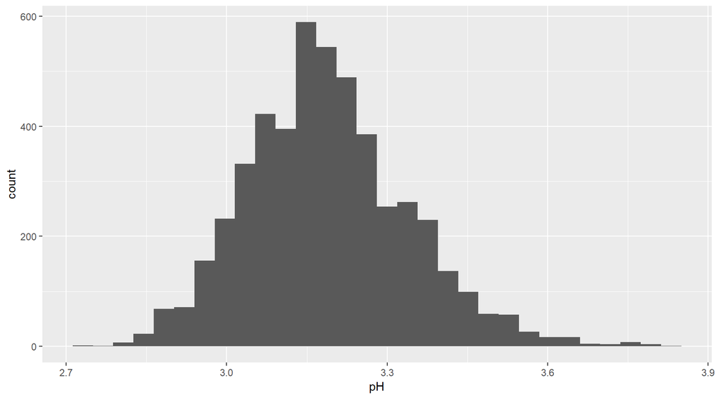

Again, a nice normal distribution.

Finally, I will be interested in free and total sulfur dioxide.

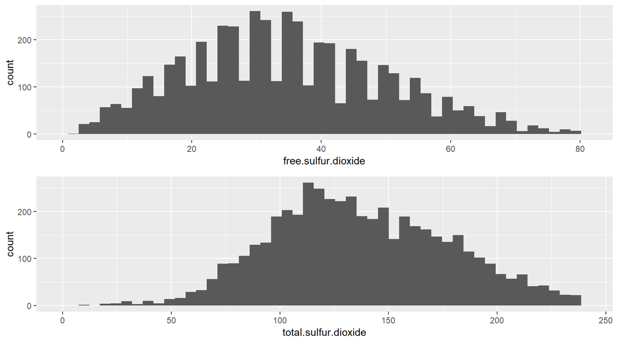

Each has a normal distribution. Free Sulfur Dioxide has curious breaks in its bins, but this may be an artifact of the binning. If I reduce the number of bins the breaks disappear, but I kept it as is in case this behavior becomes important in the future.

# Univariate Analysis

# Bivariate Plots

I will start with a scatter matrix, comparing all variables against one another and calculating correlation coefficients in one step.

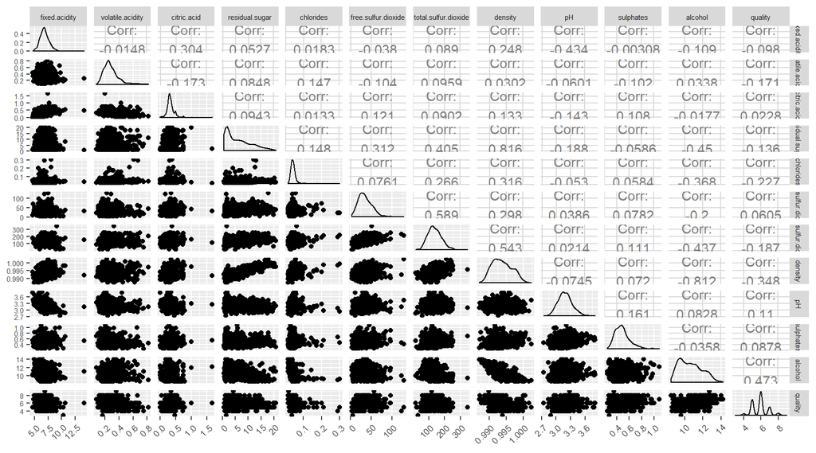

I will first look at density versus quality with two plots.

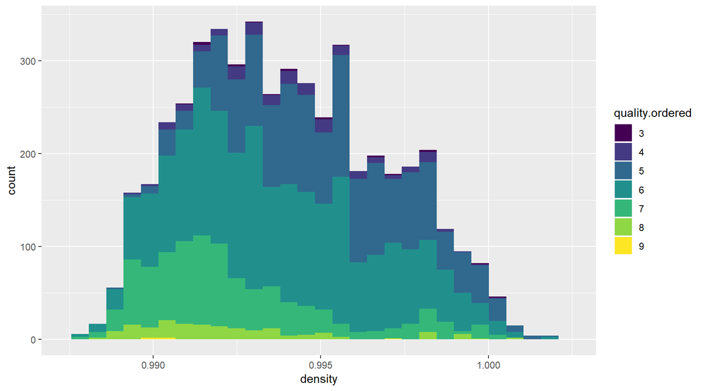

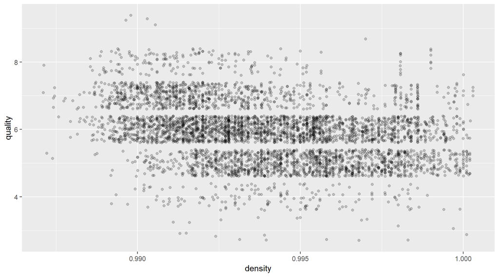

Here we see the relationship between density in two plots. As I hypothesized, there appears to be a weak relationship between density and quality. From my research I know that a low density is associated with a high alcohol content, so I will look to see if the same behavior exists with alcohol content.

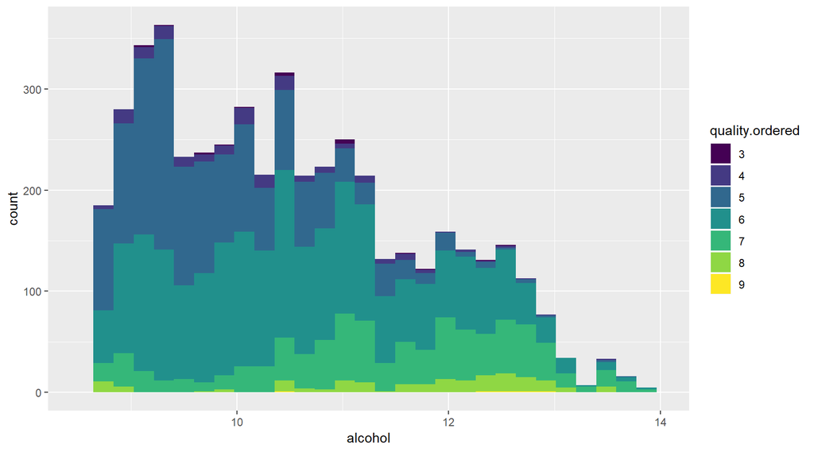

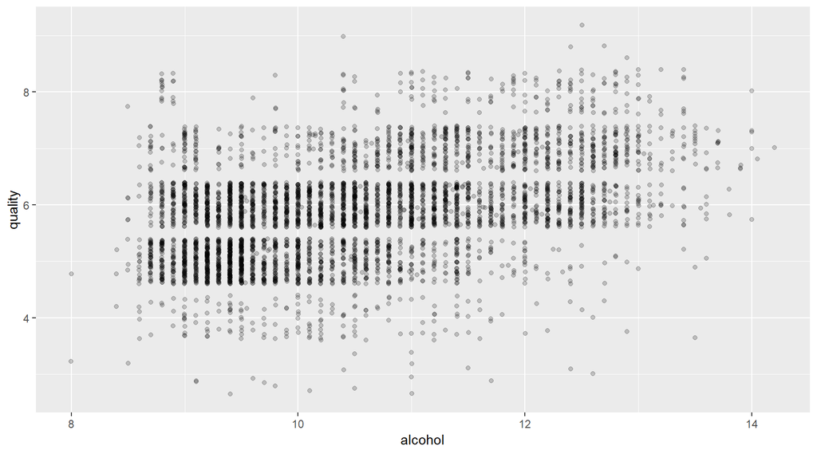

As expected, higher alcohol content does appear to be associated with higher quality ratings. The first chart may be more revealing than the second in that we see a few higher quality ratings even though the number of high alcohol content samples is lower! Another way of visualizing this relationship is with a boxplot, as follows.

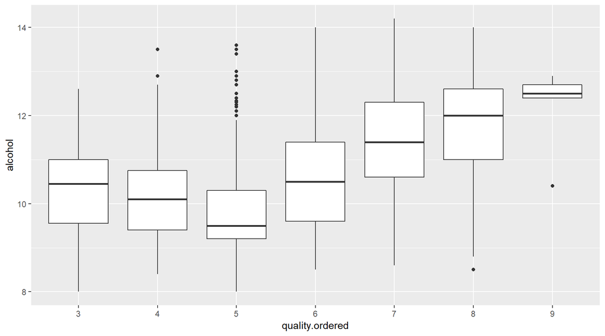

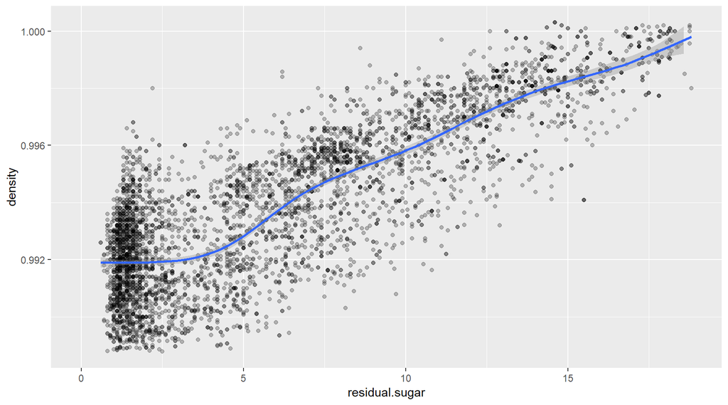

It should not be surprising that as residual sugar rises, so does density, as sugar is what is consumed in the fermentation process to produce alcohol, and alcohol has a low density.

Next I will see if I can flesh out more complex relationships, particularly relating to quality

# Bivariate Analysis

In this section I found that no supporting variables have a particularly strong relationship with the main variable, quality. However, both density and alcohol content do correlate weakly with quality. Low density and high alcohol content are both associated with higher quality ratings on average. The scatter matrix also revealed a strong correlation between density and residual sugar, which I replotted with a smooth curve to demonstrate the relationship.

# Multivariate Plots

The scatter matrix showed that none of the variables for acidity had a strong relationship directly with quality, but I might be able to derive on if I can find a relationship between those supporting variables themselves. I know that pH is a measure of acidity, so I would expect the pH variable to correlate somehow with the amount of acid in a wine.

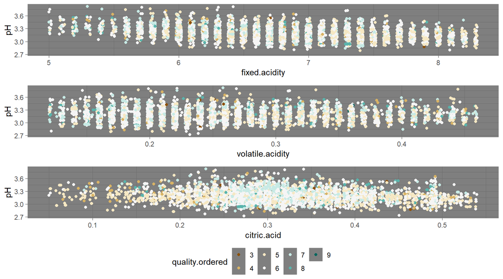

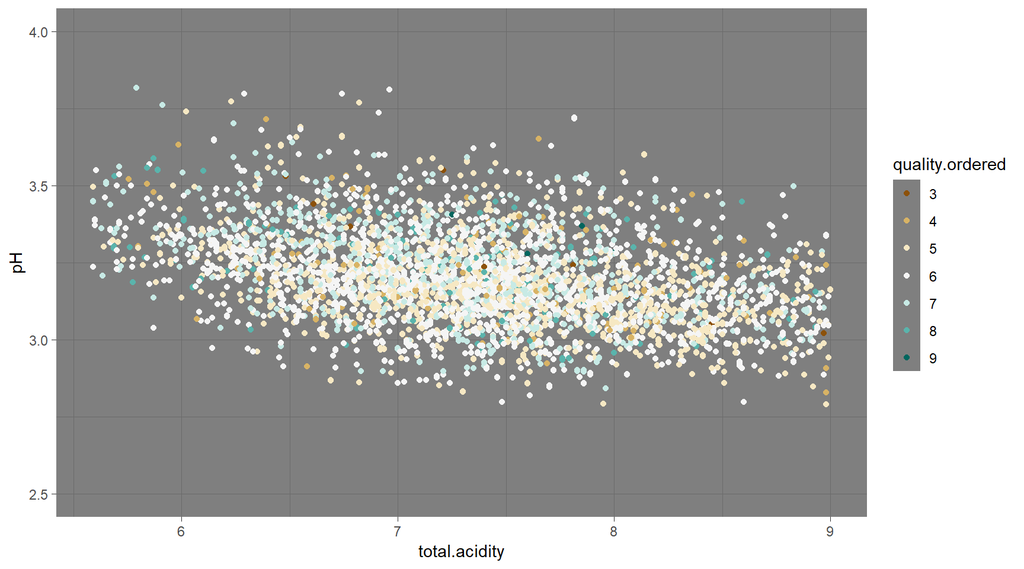

As expected, we see that as total acidity increases, pH decreases slightly. There does not appear to be any correlation between pH and quality, or acidity and quality. Total Acidity is affected primarily by fixed acidity, and very little by volatile or citric acidity.

I would also expect there to be a relationship between free and total sulfur dioxide. I will repeat the above colored scatter plot for total.sulfur.dioxide and free.sulfur.dioxide versus quality.

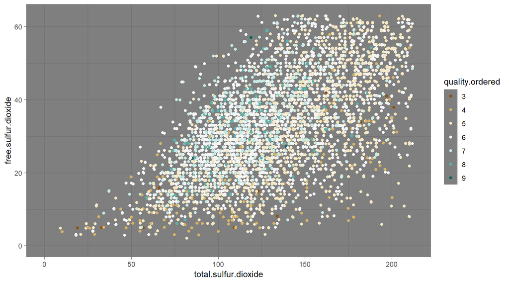

There appears to be a ‘sweet spot’ for free sulfur dioxide and total sulfur dioxide where one area between 30-50 mg/L free sulfur dioxide and 75-125 mg/L total sulfur dioxide has a higher density of 7+ quality ratings. I will indlude these variables in a model I make later to see if they lend themselves to predicting quality because of this.

The strongest correlation between any two variables on the scatter matrix was between density and residual sugar, which makes sense because as sugar is consumed by the fermentation process it will be converted into alcohol, which has a lower density. Knowing this, I will see if there is any correlation between density and residual.sugar vs quality.

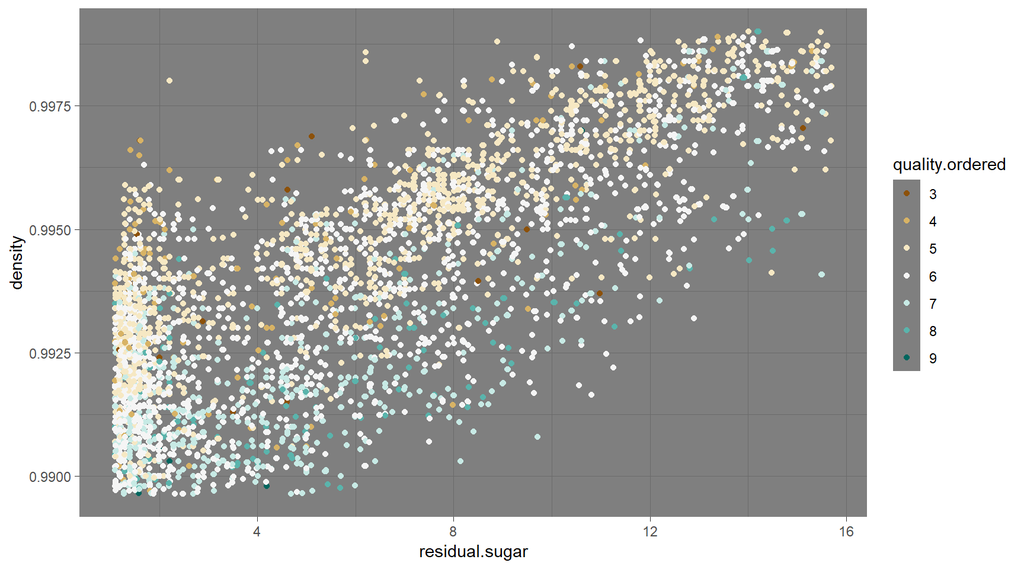

Here we finally see a complex relationship. As expected, as residual sugar rises, so does density. But what we also see is that if we hold residual sugar constant and raise the density, quality goes down. This could imply that there is a imbalance in sugar and alcohol, resulting in a wine that is too sweet. Let’s try repeating the plot with alcohol instead of density to see what that yields.

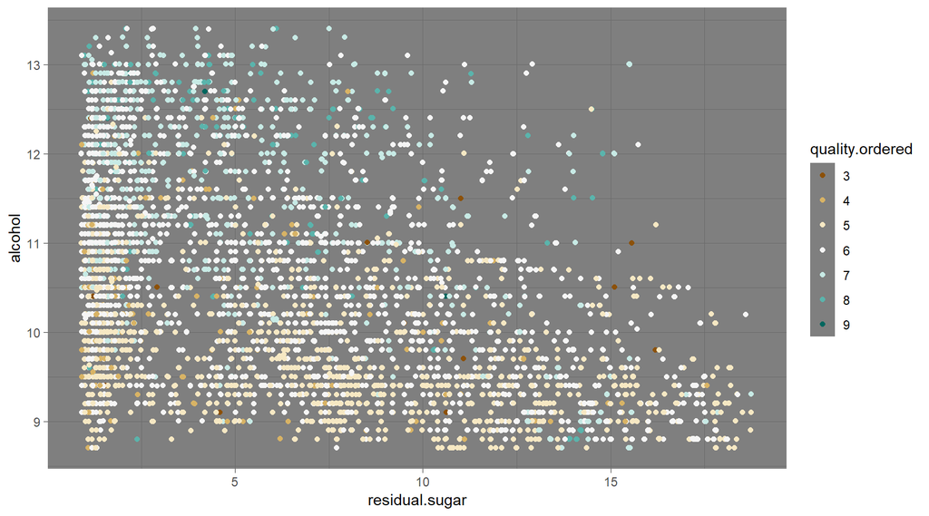

This plot shows what we saw before, that higher alcohol contents are often rated higher quality. But it does not reveal any deeper trends other than that very few wines have both high residual sugar and high alcohol content.

Using some of the variables I have used already, I will try generating a model and seeing how well it can explain variations in quality.

```
##
## Calls:
## m1: lm(formula = quality ~ alcohol, data = wq)
## m2: lm(formula = quality ~ alcohol + density, data = wq)
## m3: lm(formula = quality ~ alcohol + density + residual.sugar, data = wq)
## m4: lm(formula = quality ~ alcohol + density + residual.sugar + free.sulfur.dioxide,
##     data = wq)
## m5: lm(formula = quality ~ alcohol + density + residual.sugar + free.sulfur.dioxide +
##     total.sulfur.dioxide, data = wq)
## m6: lm(formula = quality ~ alcohol + density + residual.sugar + free.sulfur.dioxide +
##     total.sulfur.dioxide + pH, data = wq)
##
## ============================================================================================================
##                              m1            m2            m3            m4            m5            m6
## ------------------------------------------------------------------------------------------------------------
##   (Intercept)               2.582***    -22.492***     90.313***     85.267***     70.578***     95.056***
##                            (0.098)       (6.165)      (12.374)      (12.323)      (12.875)      (13.287)
##   alcohol                   0.313***      0.360***      0.246***      0.262***      0.267***      0.231***
##                            (0.009)       (0.015)       (0.018)       (0.018)       (0.018)       (0.019)
##   density                                24.728***    -87.886***    -83.131***    -68.242***    -94.315***
##                                          (6.079)      (12.317)      (12.264)      (12.834)      (13.311)
##   residual.sugar                                        0.053***      0.048***      0.044***      0.056***
##                                                        (0.005)       (0.005)       (0.005)       (0.005)
##   free.sulfur.dioxide                                                 0.005***      0.007***      0.007***
##                                                                      (0.001)       (0.001)       (0.001)
##   total.sulfur.dioxide                                                             -0.001***     -0.001***
##                                                                                    (0.000)       (0.000)
##   pH                                                                                              0.548***
##                                                                                                  (0.079)
## ------------------------------------------------------------------------------------------------------------
##   R-squared                 0.190         0.192         0.210         0.219         0.222         0.229
##   adj. R-squared            0.190         0.192         0.210         0.219         0.221         0.228
##   sigma                     0.797         0.796         0.787         0.783         0.782         0.778
##   F                      1146.395       583.290       434.085       343.354       278.480       242.384
##   p                         0.000         0.000         0.000         0.000         0.000         0.000
##   Log-likelihood        -5839.391     -5831.127     -5776.812     -5748.737     -5741.217     -5717.098
##   Deviance               3112.257      3101.773      3033.737      2999.157      2989.962      2960.660
##   AIC                   11684.782     11670.255     11563.624     11509.474     11496.434     11450.197
##   BIC                   11704.272     11696.241     11596.107     11548.453     11541.910     11502.169
##   N                      4898          4898          4898          4898          4898          4898
## ============================================================================================================
```

Evidently, the linear model does a very poor job of fitting the dataset. The correlation coefficient using 6 variables was only .229. Interestingly, the best predictor remained to be alcohol, which has a .190 correlation coefficient by itself.

# Multivariate Analysis

The primary relationships observed in the multivariate cases were those between density, alcohol, residual sugar, and quality. As expected, alcohol is inversely correlated with density, which is positively correlated with residual sugar. The relationship I was not expecting was between free and total sulphur dioxide and quality, where there appeared to be a ‘sweet spot’ for quality. Again this could have to do with a ‘balance’ of some kind, or it could be related to some other variable which I did not investigate.

The 6 degree linear model I created did a very poor job fitting the quality variable, which suggests that even among variables that exhibited some kind of a relationship with quality, the relationship is nonlinear or incomplete.

# Final Plots and Summary

### First Plot

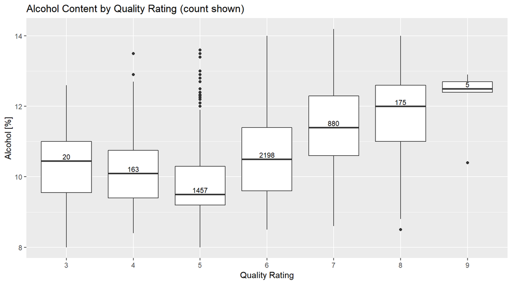

### Description 1

This plot shows the median and IQR of alcohol content per quality rating, and I have also added the count of samples per rating to each box. It is evident that the highest rated wines have the highest alcohol content, but that the opposite end of the scale also shows a lift in alcohol ratings, possibly because the lowest end wines are intended to be strong if not tasty. Meanwhile the high end options are ones that can blend taste with strength. Or perhaps the raters just rate higher when they are inebriated.

### Second Plot

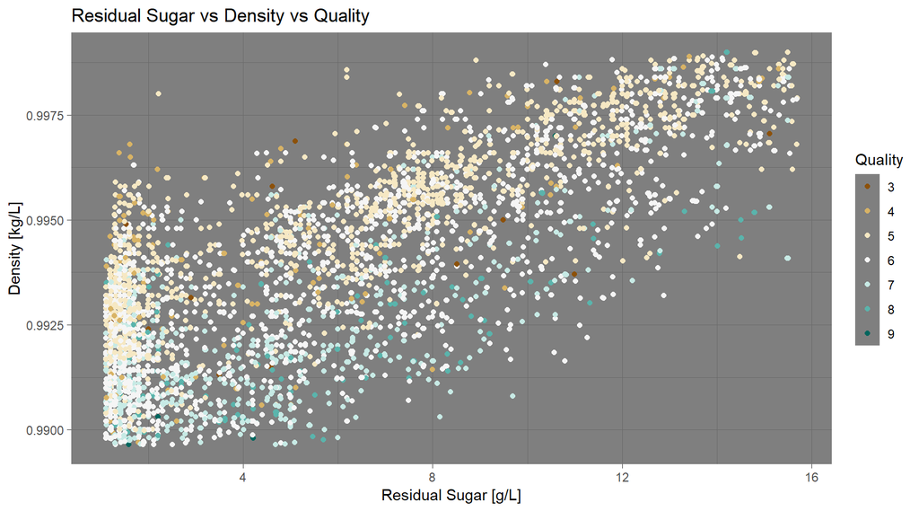

### Third Plot

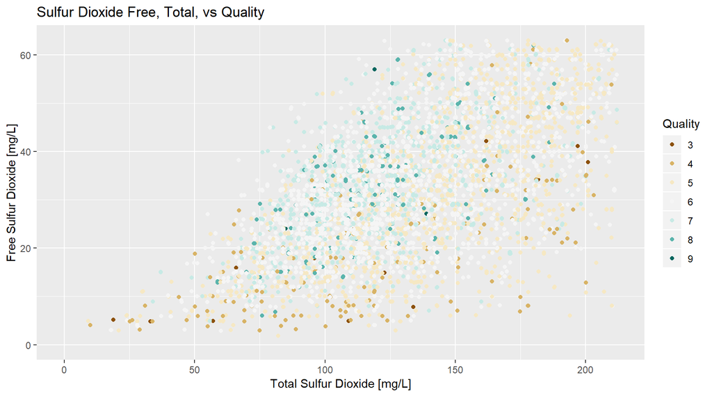

### Description 3

This plot shows the relationship of total and free sulfur dioxide. As expected, total sulfur dioxide rises with free sulfur dioxide. What is interesting about this plot is that there is a ‘sweet spot’ in terms of wine quality right in the middle of the plot. It is unclear to me why this is, and I was not able to uncover strong relationships between sulfur and other variables in this dataset, so that is something that I would like to investigate further in the future.

# Reflection

This was a challenging dataset, because as was made clear by the scatter matrix, there are very few ostensible correlations between individual variables. Through some pseudo-random experimentation I was able to flesh out some interesting interactions, particularly relating to density, alcohol, residual sugar, total and free sulfur dioxide, and quality, but I was not able to tie them all together in an effective model. What was surprising to me was that of all variables, it seems that alcohol content by itself was easily the best predictor of quality. It would have been useful to have more info on wines beyond chemical composition, such as year, vineyard, price etc. Without more info to go on, my best advice when wine shopping is just to buy the strong stuff. According to this dataset, if you aim for >= 12.8% ABV, you are more likely than not to get above average quality wine!